# Table of Contents

## Categories of passengers most likely to survive the Titanic disaster.

Beyond gender, passenger class was the greatest predictive variable. A male travelling first class had a higher survival rate than a male travelling either second or third class. First class passengers had a higher survival rate than second class passengers, who had a higher survival rate than third class passengers.

Historic Survival Rate Table

The following algorithms were utilized during the course of this analysis;

- Decision Tree
- Gaussian
- Gradient Boosting
- K Neighbors
- Logistic Regression
- Multi Layer Perceptron
- Random Forest
- Stochastic Gradient Descent
- Support Vector

In addition to examining passengers as a whole, passengers were also divided into groupings by gender and passenger class.

As expected, in accordance with the policy of women and children first, survivability was higher at younger ages. However, no abrupt drop-off in survivability was observed at a certain age. This would suggest that the crew putting passengers on to life boats were not applying any specific cut-off age at which a passenger was no longer considered a child. The drop in survivability by age was gradual and uniform across most models. A slight advantage can be seen with children under ten years of age. Possibilty because these children could occupy the same seat as the mother.

As expected, models predicting from hypothetical passenger features show that; females had a higher survivability probability than males, and that survivability decreased by passenger class.

When considering familial relationships, passengers travelling by themselves showed a higher survivability rate on some models. This may be accounted for in instances where there was only one seat left available in a life boat. This advantage probably accured primarily to females.

Passengers consisting of a single parent and a child had the second highest survivability, possibly because the single parent may be male.

## Detailed explanation of the logic of the analysis

Children younger than one year old will be considered to be one year old, since it is assumed that the difference in age would not affect survivability. Missing ages were assigned by the average of gender and passenger class.

The primary survival differentiators were determined to be; gender, passenger class, and familial relationships. Subgroupings were created in accordance with these differentiators. Passenger data for all passengers was examined as well. Historical survivability was then calculated for each group by simply dividing survived by the group total.

These groups then formed the basis for the machine learning algorithms described previously. These models were then used to examine familial relationship and age predictors on survivability. This was accomplished by creating a hypothetical group of passengers where each unique combination of; gender, passenger class, familial relationship was created for each age present on the ship. Survivability was then predicted using all models against this data set.

## Other attributes used for the analysis.

- Pclass, used in derived form, broken out into three columns for each possible categorical value.
- Sex, used in a derived form, broken out into two columns for each possible categorical value.
- SibSp, used in derived form, as described below.
- Parch, used in derived form, as described below.

## Complete list of all attributes used.

- Survived.
- Pclass, used in derived form, broken out into three columns for each possible categorical value.
- Sex, used in a derived form, broken out into two columns for each possible categorical value.
- Age.
- SibSp, used in derived form, as described below.
- Parch, used in derived form, as described below.

## Engineered attributes

In order to examine whether the decision to remain on board was in some way affected by whether the passenger was travelling alone or with others, three new columns were added based on the existing 'SibSp' and 'Parch' columns. Columns 'WithSiblingSpouse', 'WithParent', and 'WithFamily' were added. True values derived as follows;

- WithSiblingSpouse true if SibSp is greater than zero
- WithParent true if Parch greater than zero
- WithFamily true if SibSp greater than zero and Parch greater than zero.

The addition of these columns produced mixed results. The highest predictive accuracies when examining all passengers were obtained from algorithms when including familial features. This would suggest that familial considerations were taken into account.

All Passenger Predictions

[output not shown]

Female Predictions

[output not shown]

When examining the male subgroup, familial features did produce higher predictive accuracies. Suggesting that familial associations may have become more pertinent once the majority of women had already departed the ship.

Male Predictions

[output not shown]

Categorical values;

- Broke out Sex into two binary columns
- Broke out Pclass into three binary columns

## Excluded attributes

- PassengerId considered irrelevant.
- Name considered irrelevant.
- Ticket number considered irrelevant.
- Embark code considered irrelevant.
- Passenger number considered irrelevant.
- Cabin number considered irrelevant.
- Fare considered irrelevant.

## Missing attributes

Missing ages assigned from average by passenger class and gender.

Average Age

```python
import matplotlib.pyplot as plt
import numpy as np
import pandas as pd
import seaborn as sns
import statistics as st
import statsmodels.api as sm
import warnings

from statistics import mean

from sklearn import svm
from sklearn.ensemble import GradientBoostingClassifier, RandomForestClassifier
from sklearn.linear_model import LogisticRegression, SGDClassifier
from sklearn.metrics import accuracy_score, classification_report, confusion_matrix
from sklearn.model_selection import cross_val_predict, train_test_split
from sklearn.naive_bayes import GaussianNB
from sklearn.neighbors import KNeighborsClassifier
from sklearn.neural_network import MLPClassifier
from sklearn.preprocessing import StandardScaler, LabelEncoder
from sklearn.svm import LinearSVC, SVC
from sklearn.tree import DecisionTreeClassifier

%matplotlib inline

warnings.filterwarnings('ignore')
sns.set()

class Titanic:

    file_data = ''

    average_age_list = []
    average_age_df = []

    female_third_class_ages = []
    female_second_class_ages = []
    female_first_class_ages = []
    female_ages = []
    male_third_class_ages = []
    male_second_class_ages = []
    male_first_class_ages = []
    male_ages = []
    third_class_ages = []
    second_class_ages = []
    first_class_ages = []
    all_passengers_ages = []

    survival_summary_list = []
    survival_summary_df = []

    age_count_summary = []

    female_third_class = pd.DataFrame()
    female_second_class = pd.DataFrame()
    female_first_class = pd.DataFrame()
    female = pd.DataFrame()
    male_third_class = pd.DataFrame()
    male_second_class = pd.DataFrame()
    male_first_class = pd.DataFrame()
    male = pd.DataFrame()

    third_class = pd.DataFrame()
    second_class = pd.DataFrame()
    first_class = pd.DataFrame()

    all_passengers = pd.DataFrame()

    hypothetical_predictions = pd.DataFrame()

    def load_file(self, file_name):

        self.file_data = pd.read_csv(file_name)
        self.file_data.info()

    def preprocess_data(self):

        for passenger_key, passenger_data in self.file_data.iterrows():

            if passenger_data['Age'] < 1:
                self.file_data.loc[passenger_key, 'Age'] = 1

            if passenger_data['SibSp'] != 0:
                self.file_data.loc[passenger_key, 'WithSiblingSpouse'] = 1
            else:
                self.file_data.loc[passenger_key, 'WithSiblingSpouse'] = 0

            if passenger_data['Parch'] != 0:
                self.file_data.loc[passenger_key, 'WithParent'] = 1
            else:
                self.file_data.loc[passenger_key, 'WithParent'] = 0

            if passenger_data['SibSp'] != 0 and passenger_data['Parch'] != 0:
                self.file_data.loc[passenger_key, 'WithFamily'] = 1
            else:
                self.file_data.loc[passenger_key, 'WithFamily'] = 0

            if passenger_data['Sex'] == 'female':
                self.file_data.loc[passenger_key, 'Male'] = 0
                self.file_data.loc[passenger_key, 'Female'] = 1
            elif passenger_data['Sex'] == 'male':
                self.file_data.loc[passenger_key, 'Male'] = 1
                self.file_data.loc[passenger_key, 'Female'] = 0

            if passenger_data['Pclass'] == 1:
                self.file_data.loc[passenger_key, 'FirstClass'] = 1
                self.file_data.loc[passenger_key, 'SecondClass'] = 0
                self.file_data.loc[passenger_key, 'ThirdClass'] = 0
            elif passenger_data['Pclass'] == 2:
                self.file_data.loc[passenger_key, 'FirstClass'] = 0
                self.file_data.loc[passenger_key, 'SecondClass'] = 1
                self.file_data.loc[passenger_key, 'ThirdClass'] = 0
            elif passenger_data['Pclass'] == 3:
                self.file_data.loc[passenger_key, 'FirstClass'] = 0
                self.file_data.loc[passenger_key, 'SecondClass'] = 0
                self.file_data.loc[passenger_key, 'ThirdClass'] = 1

        self.all_passengers = self.file_data.copy()
        self.all_passengers_ages = self.file_data[(pd.isna(self.file_data['Age']) == False)].loc[:, 'Age'].copy()

        self.male = self.file_data[(self.file_data['Sex'] == 'male')].copy()
        self.male_ages = self.file_data[(pd.isna(self.file_data['Age']) == False) & \
                                        (self.file_data['Sex'] == 'male')].loc[:, 'Age'].copy()
        self.male_first_class = self.file_data[(self.file_data['Sex'] == 'male') & (self.file_data['Pclass'] == 1)].copy()
        self.male_first_class_ages = self.file_data[(pd.isna(self.file_data['Age']) == False) & \
                                                    (self.file_data['Sex'] == 'male') & \
                                                    (self.file_data['Pclass'] == 1)].loc[:, 'Age'].copy()
        self.male_second_class = self.file_data[(self.file_data['Sex'] == 'male') & (self.file_data['Pclass'] == 2)].copy()
        self.male_second_class_ages = self.file_data[(pd.isna(self.file_data['Age']) == False) & \
                                                    (self.file_data['Sex'] == 'male') & \
                                                    (self.file_data['Pclass'] == 2)].loc[:, 'Age'].copy()
        self.male_third_class = self.file_data[(self.file_data['Sex'] == 'male') & (self.file_data['Pclass'] == 3)].copy()
        self.male_third_class_ages = self.file_data[(pd.isna(self.file_data['Age']) == False) & \
                                                    (self.file_data['Sex'] == 'male') & \
                                                    (self.file_data['Pclass'] == 3)].loc[:, 'Age'].copy()

        self.female = self.file_data[(self.file_data['Sex'] == 'female')].copy()
        self.female_ages = self.file_data[(pd.isna(self.file_data['Age']) == False) & \
                                        (self.file_data['Sex'] == 'female')].loc[:, 'Age'].copy()
        self.female_first_class = self.file_data[(self.file_data['Sex'] == 'female') & (self.file_data['Pclass'] == 1)].copy()
        self.female_first_class_ages = self.file_data[(pd.isna(self.file_data['Age']) == False) & \
                                                    (self.file_data['Sex'] == 'female') & \
                                                    (self.file_data['Pclass'] == 1)].loc[:, 'Age'].copy()
        self.female_second_class = self.file_data[(self.file_data['Sex'] == 'female') & (self.file_data['Pclass'] == 2)].copy()
        self.female_second_class_ages = self.file_data[(pd.isna(self.file_data['Age']) == False) & \
                                                    (self.file_data['Sex'] == 'female') & \
                                                    (self.file_data['Pclass'] == 2)].loc[:, 'Age'].copy()
        self.female_third_class = self.file_data[(self.file_data['Sex'] == 'female') & (self.file_data['Pclass'] == 3)].copy()
        self.female_third_class_ages = self.file_data[(pd.isna(self.file_data['Age']) == False) & \
                                                    (self.file_data['Sex'] == 'female') & \
                                                    (self.file_data['Pclass'] == 1)].loc[:, 'Age'].copy()
```

```python
        self.first_class = self.file_data[(self.file_data['Pclass'] == 1)].copy()
        self.first_class_ages = self.file_data[(pd.isna(self.file_data['Age']) == False) & \
                                                    (self.file_data['Pclass'] == 1)].loc[:, 'Age'].copy()
        self.second_class = self.file_data[(self.file_data['Pclass'] == 2)].copy()
        self.second_class_ages = self.file_data[(pd.isna(self.file_data['Age']) == False) & \
                                                    (self.file_data['Pclass'] == 2)].loc[:, 'Age'].copy()
        self.third_class = self.file_data[(self.file_data['Pclass'] == 3)].copy()
        self.third_class_ages = self.file_data[(pd.isna(self.file_data['Age']) == False) & \
                                                    (self.file_data['Pclass'] == 3)].loc[:, 'Age'].copy()

    def average_age(self):

        self.average_age_list.append(['Female Third Class', round(self.female_third_class_ages.mean())])
        self.average_age_list.append(['Female Second Class', round(self.female_second_class_ages.mean())])
        self.average_age_list.append(['Female First Class', round(self.female_first_class_ages.mean())])
        self.average_age_list.append(['Male Third Class', round(self.male_third_class_ages.mean())])
        self.average_age_list.append(['Male Second_class', round(self.male_second_class_ages.mean())])
        self.average_age_list.append(['Male First_class', round(self.male_first_class_ages.mean())])
        self.average_age_list.append(['Female', round(self.female_ages.mean())])
        self.average_age_list.append(['Male', round(self.male_ages.mean())])
        self.average_age_list.append(['Third Class', round(self.third_class_ages.mean())])
        self.average_age_list.append(['Second Class', round(self.second_class_ages.mean())])
        self.average_age_list.append(['First Class', round(self.first_class_ages.mean())])
        self.average_age_list.append(['All Passengers', round(self.all_passengers_ages.mean())])

        self.average_age_df = pd.DataFrame(self.average_age_list, columns = ['Passenger Type', 'Average Age'])

        sns.barplot(data = self.average_age_df, x = 'Average Age', y = 'Passenger Type')

    def assign_missing_ages(self):

        self.file_data.loc[((pd.isna(self.file_data['Age'])) & \
                         (self.file_data['Pclass'] == 3) & \
                         (self.file_data['Sex'] == 'female')), 'Age'] = self.average_age_list[0][1]
        self.file_data.loc[((pd.isna(self.file_data['Age'])) & \
                         (self.file_data['Pclass'] == 2) & \
                         (self.file_data['Sex'] == 'female')), 'Age'] = self.average_age_list[1][1]
        self.file_data.loc[((pd.isna(self.file_data['Age'])) & \
                         (self.file_data['Pclass'] == 1) & \
                         (self.file_data['Sex'] == 'female')), 'Age'] = self.average_age_list[2][1]
        self.file_data.loc[((pd.isna(self.file_data['Age'])) & \
                         (self.file_data['Pclass'] == 3) & \
                         (self.file_data['Sex'] == 'male')), 'Age'] = self.average_age_list[3][1]
        self.file_data.loc[((pd.isna(self.file_data['Age'])) & \
                         (self.file_data['Pclass'] == 2) & \
                         (self.file_data['Sex'] == 'male')), 'Age'] = self.average_age_list[4][1]
        self.file_data.loc[((pd.isna(self.file_data['Age'])) & \
                         (self.file_data['Pclass'] == 1) & \
                         (self.file_data['Sex'] == 'male')), 'Age'] = self.average_age_list[5][1]
        self.file_data.info()

        self.all_passengers.loc[((pd.isna(self.all_passengers['Age'])) & \
                         (self.all_passengers['Pclass'] == 3) & \
                         (self.all_passengers['Sex'] == 'female')), 'Age'] = self.average_age_list[0][1]
        self.all_passengers.loc[((pd.isna(self.all_passengers['Age'])) & \
                         (self.all_passengers['Pclass'] == 2) & \
                         (self.all_passengers['Sex'] == 'female')), 'Age'] = self.average_age_list[1][1]
        self.all_passengers.loc[((pd.isna(self.all_passengers['Age'])) & \
                         (self.all_passengers['Pclass'] == 1) & \
                         (self.all_passengers['Sex'] == 'female')), 'Age'] = self.average_age_list[2][1]
        self.all_passengers.loc[((pd.isna(self.all_passengers['Age'])) & \
                         (self.all_passengers['Pclass'] == 3) & \
                         (self.all_passengers['Sex'] == 'male')), 'Age'] = self.average_age_list[3][1]
        self.all_passengers.loc[((pd.isna(self.all_passengers['Age'])) & \
                         (self.all_passengers['Pclass'] == 2) & \
                         (self.all_passengers['Sex'] == 'male')), 'Age'] = self.average_age_list[4][1]
        self.all_passengers.loc[((pd.isna(self.all_passengers['Age'])) & \
                         (self.all_passengers['Pclass'] == 1) & \
                         (self.all_passengers['Sex'] == 'male')), 'Age'] = self.average_age_list[5][1]
        self.all_passengers.info()

        self.male.loc[((pd.isna(self.male['Age'])) & \
                         (self.male['Pclass'] == 3)), 'Age'] = self.average_age_list[3][1]
        self.male.loc[((pd.isna(self.male['Age'])) & \
                         (self.male['Pclass'] == 2)), 'Age'] = self.average_age_list[4][1]
        self.male.loc[((pd.isna(self.male['Age'])) & \
                         (self.male['Pclass'] == 1)), 'Age'] = self.average_age_list[5][1]
        self.male.info()

        self.male_first_class.loc[(pd.isna(self.male_first_class['Age'])), 'Age'] = self.average_age_list[5][1]
        self.male_first_class.info()

        self.male_second_class.loc[(pd.isna(self.male_second_class['Age'])), 'Age'] = self.average_age_list[4][1]
        self.male_second_class.info()

        self.male_third_class.loc[(pd.isna(self.male_third_class['Age'])), 'Age'] = self.average_age_list[3][1]
        self.male_third_class.info()
```

```python
        self.female.loc[((pd.isna(self.female['Age'])) & \
                         (self.female['Pclass'] == 3)), 'Age'] = self.average_age_list[0][1]
        self.female.loc[((pd.isna(self.female['Age'])) & \
                         (self.female['Pclass'] == 2)), 'Age'] = self.average_age_list[1][1]
        self.female.loc[((pd.isna(self.female['Age'])) & \
                         (self.female['Pclass'] == 1)), 'Age'] = self.average_age_list[2][1]
        self.female.info()

        self.female_first_class.loc[(pd.isna(self.female_first_class['Age'])), 'Age'] = self.average_age_list[2][1]
        self.female_first_class.info()

        self.female_second_class.loc[(pd.isna(self.female_second_class['Age'])), 'Age'] = self.average_age_list[1][1]
        self.female_second_class.info()

        self.female_third_class.loc[(pd.isna(self.female_third_class['Age'])), 'Age'] = self.average_age_list[0][1]
        self.female_third_class.info()

        self.first_class.loc[((pd.isna(self.first_class['Age'])) & \
                             (self.first_class['Sex'] == 'female')), 'Age'] = self.average_age_list[2][1]
        self.first_class.loc[((pd.isna(self.first_class['Age'])) & \
                             (self.first_class['Sex'] == 'male')), 'Age'] = self.average_age_list[5][1]
        self.first_class.info()

        self.second_class.loc[((pd.isna(self.second_class['Age'])) & \
                             (self.second_class['Sex'] == 'female')), 'Age'] = self.average_age_list[1][1]
        self.second_class.loc[((pd.isna(self.second_class['Age'])) & \
                             (self.second_class['Sex'] == 'male')), 'Age'] = self.average_age_list[4][1]
        self.second_class.info()

        self.third_class.loc[((pd.isna(self.third_class['Age'])) & \
                             (self.third_class['Sex'] == 'female')), 'Age'] = self.average_age_list[0][1]
        self.third_class.loc[((pd.isna(self.third_class['Age'])) & \
                             (self.third_class['Sex'] == 'male')), 'Age'] = self.average_age_list[3][1]
        self.third_class.info()

    def survival_summary(self):

        self.survival_summary_list.append(['Female', \
        (self.female.loc[:, 'Survived'].sum() / self.female.loc[:, 'Survived'].count())])

        self.survival_summary_list.append(['Female First Class', \
        (self.female_first_class.loc[:, 'Survived'].sum() / self.female_first_class.loc[:, 'Survived'].count())])

        self.survival_summary_list.append(['Female Second Class', \
        (self.female_second_class.loc[:, 'Survived'].sum() / self.female_second_class.loc[:, 'Survived'].count())])

        self.survival_summary_list.append(['Female Third Class', \
        (self.female_third_class.loc[:, 'Survived'].sum() / self.female_third_class.loc[:, 'Survived'].count())])

        self.survival_summary_list.append(['Male', \
        (self.male.loc[:, 'Survived'].sum() / self.male.loc[:, 'Survived'].count())])

        self.survival_summary_list.append(['Male First Class', \
        (self.male_first_class.loc[:, 'Survived'].sum() / self.male_first_class.loc[:, 'Survived'].count())])

        self.survival_summary_list.append(['Male Second Class', \
        (self.male_second_class.loc[:, 'Survived'].sum() / self.male_second_class.loc[:, 'Survived'].count())])

        self.survival_summary_list.append(['Male Third Class', \
        (self.male_third_class.loc[:, 'Survived'].sum() / self.male_third_class.loc[:, 'Survived'].count())])

        self.survival_summary_list.append(['First Class', \
        (self.first_class.loc[:, 'Survived'].sum() / self.first_class.loc[:, 'Survived'].count())])

        self.survival_summary_list.append(['Second Class', \
        (self.second_class.loc[:, 'Survived'].sum() / self.second_class.loc[:, 'Survived'].count())])

        self.survival_summary_list.append(['Third Class', \
        (self.third_class.loc[:, 'Survived'].sum() / self.third_class.loc[:, 'Survived'].count())])

        self.survival_summary_list.append(['All Passengers', \
        (self.all_passengers.loc[:, 'Survived'].sum() / self.all_passengers.loc[:, 'Survived'].count())])

        self.survival_summary_df = pd.DataFrame(self.survival_summary_list, columns = ['Passenger Type', 'Survival Probability'])

        sns.barplot(data = self.survival_summary_df, x = 'Survival Probability', y = 'Passenger Type')

    def run_algorithm(self, \
                      algorithm, \
                      predictive_features_train, \
                      predictive_features_test, \
                      targets_train, \
                      targets_test, \
                      passenger_ages, \
                      include_familial, \
                      include_gender, \
                      algorithm_description):

        classifier = algorithm
        classifier.fit(predictive_features_train, targets_train)
        prediction = classifier.predict(predictive_features_test)

        print(classification_report(targets_test, prediction))

        self.hypothetical_passengers(passenger_ages, include_familial, include_gender, classifier, algorithm_description)

    def non_familial_models(self, population_subset, passenger_ages, include_gender):

        targets = population_subset.loc[:, 'Survived']
        predictive_features = population_subset.loc[:,\
        ['Age', 'Male', 'Female', 'FirstClass', 'SecondClass', 'ThirdClass']]

        predictive_features_train, \
        predictive_features_test, \
        targets_train, \
        targets_test = train_test_split(predictive_features, \
                                        targets, test_size = 0.2, \
                                        random_state = 42)

        targets_train = np.ravel(targets_train)

        scaler = StandardScaler()

        scaler.fit(predictive_features_train)
        predictive_features_train_scaled = scaler.transform(predictive_features_train)
        predictive_features_test_scaled = scaler.transform(predictive_features_test)
```

```python
        print('Gradient Boosting')

        self.run_algorithm(GradientBoostingClassifier(), \
                      predictive_features_train_scaled, \
                      predictive_features_test_scaled, \
                      targets_train, \
                      targets_test, \
                      passenger_ages, \
                      False, \
                      include_gender, \
                      'Gradient Boosting')

        print('Decision Tree')

        self.run_algorithm(DecisionTreeClassifier(), \
                      predictive_features_train_scaled, \
                      predictive_features_test_scaled, \
                      targets_train, \
                      targets_test, \
                      passenger_ages, \
                      False, \
                      include_gender, \
                      'Decision Tree')

        print('Stochastic Gradient Descent')

        self.run_algorithm(SGDClassifier(), \
                      predictive_features_train_scaled, \
                      predictive_features_test_scaled, \
                      targets_train, \
                      targets_test, \
                      passenger_ages, \
                      False, \
                      include_gender, \
                      'Stochastic Gradient Descent')

        print('Gaussian')

        self.run_algorithm(GaussianNB(), \
                      predictive_features_train_scaled, \
                      predictive_features_test_scaled, \
                      targets_train, \
                      targets_test, \
                      passenger_ages, \
                      False, \
                      include_gender, \
                      'Gaussian')

        print('Logistic Regression')

        self.run_algorithm(LogisticRegression(), \
                      predictive_features_train_scaled, \
                      predictive_features_test_scaled, \
                      targets_train, \
                      targets_test, \
                      passenger_ages, \
                      False, \
                      include_gender, \
                      'Logistic Regression')

        print('K Neighbors')

        self.run_algorithm(KNeighborsClassifier(), \
                      predictive_features_train_scaled, \
                      predictive_features_test_scaled, \
                      targets_train, \
                      targets_test, \
                      passenger_ages, \
                      False, \
                      include_gender, \
                      'K Neighbors')

        print('Random Forest')

        self.run_algorithm(RandomForestClassifier(n_estimators = 200), \
                      predictive_features_train_scaled, \
                      predictive_features_test_scaled, \
                      targets_train, \
                      targets_test, \
                      passenger_ages, \
                      False, \
                      include_gender, \
                      'Random Forest')

        print('Support Vector')

        self.run_algorithm(svm.SVC(), \
                      predictive_features_train_scaled, \
                      predictive_features_test_scaled, \
                      targets_train, \
                      targets_test, \
                      passenger_ages, \
                      False, \
                      include_gender, \
                      'Support Vector')

        print('Multi Layer Perceptron')

        classifier = MLPClassifier(hidden_layer_sizes = (6,6,6), max_iter = 500)
        classifier.fit(predictive_features_train_scaled, targets_train)
        prediction = classifier.predict(predictive_features_test_scaled)

        print(classification_report(targets_test, prediction))

        self.hypothetical_passengers(passenger_ages, False, include_gender, classifier, 'Multi Layer Perceptron')

    def familial_models(self, population_subset, passenger_ages, include_gender):

        targets = population_subset.loc[:, 'Survived']
        predictive_features_family = population_subset.loc[:, \
        ['Age', 'WithSiblingSpouse', 'WithParent', 'WithFamily', 'Male', 'Female', 'FirstClass', 'SecondClass', 'ThirdClass']]

        predictive_features_family_train, \
        predictive_features_family_test, \
        targets_train, \
        targets_test = train_test_split(predictive_features_family, \
                                        targets, test_size = 0.2, \
                                        random_state = 42)

        targets_train = np.ravel(targets_train)

        scaler = StandardScaler()

        scaler.fit(predictive_features_family_train)
        predictive_features_family_train_scaled = scaler.transform(predictive_features_family_train)
        predictive_features_family_test_scaled = scaler.transform(predictive_features_family_test)

        print('Gradient Boosting')

        self.run_algorithm(GradientBoostingClassifier(), \
                      predictive_features_family_train_scaled, \
                      predictive_features_family_test_scaled, \
                      targets_train, \
                      targets_test, \
                      passenger_ages, \
                      True, \
                      include_gender, \
                      'Gradient Boosting')

        print('Decision Tree')

        self.run_algorithm(DecisionTreeClassifier(), \
                      predictive_features_family_train_scaled, \
                      predictive_features_family_test_scaled, \
                      targets_train, \
                      targets_test, \
                      passenger_ages, \
                      True, \
                      include_gender, \
                      'Decision Tree')

        print('Stochastic Gradient Descent')

        self.run_algorithm(SGDClassifier(), \
                      predictive_features_family_train_scaled, \
                      predictive_features_family_test_scaled, \
                      targets_train, \
                      targets_test, \
                      passenger_ages, \
                      True, \
                      include_gender, \
                      'Stochastic Gradient Descent')
```

```python
        print('Gaussian')

        self.run_algorithm(GaussianNB(), \
                      predictive_features_family_train_scaled, \
                      predictive_features_family_test_scaled, \
                      targets_train, \
                      targets_test, \
                      passenger_ages, \
                      True, \
                      include_gender, \
                      'Gaussian')

        print('Logistic Regression')

        self.run_algorithm(LogisticRegression(), \
                      predictive_features_family_train_scaled, \
                      predictive_features_family_test_scaled, \
                      targets_train, \
                      targets_test, \
                      passenger_ages, \
                      True, \
                      include_gender, \
                      'Logistic Regression')

        print('K Neighbors')

        self.run_algorithm(KNeighborsClassifier(), \
                      predictive_features_family_train_scaled, \
                      predictive_features_family_test_scaled, \
                      targets_train, \
                      targets_test, \
                      passenger_ages, \
                      True, \
                      include_gender, \
                      'K Neighbors')

        print('Random Forest')

        self.run_algorithm(RandomForestClassifier(n_estimators = 200), \
                      predictive_features_family_train_scaled, \
                      predictive_features_family_test_scaled, \
                      targets_train, \
                      targets_test, \
                      passenger_ages, \
                      True, \
                      include_gender, \
                      'Random Forest')

        print('Support Vector')

        self.run_algorithm(svm.SVC(), \
                      predictive_features_family_train_scaled, \
                      predictive_features_family_test_scaled, \
                      targets_train, \
                      targets_test, \
                      passenger_ages, \
                      True, \
                      include_gender, \
                      'Support Vector')

        print('Multi Layer Perceptron')

        classifier = MLPClassifier(hidden_layer_sizes = (6,6,6), max_iter = 500)
        classifier.fit(predictive_features_family_train_scaled, targets_train)
        prediction = classifier.predict(predictive_features_family_test_scaled)

        print(classification_report(targets_test, prediction))

        self.hypothetical_passengers(passenger_ages, True, include_gender, classifier, 'Multi Layer Perceptron')

    def hypothetical_passengers(self, passenger_ages, include_familial, include_gender, classifier, algorithm_description):

        ages = []

        for age in passenger_ages:
            age = round(age)
            ages.append(age)

        ages = set(ages)

        hypothetical_features = []

        for age in ages:

            if include_familial:

                if include_gender == 'M' or include_gender == 'A':
                    hypothetical_features.append([age,0,0,0,1,0,0,0,1])
                    hypothetical_features.append([age,0,0,1,1,0,0,0,1])
                    hypothetical_features.append([age,0,1,0,1,0,0,0,1])
                    hypothetical_features.append([age,1,0,0,1,0,0,0,1])
                    hypothetical_features.append([age,0,0,0,1,0,0,1,0])
                    hypothetical_features.append([age,0,0,1,1,0,0,1,0])
                    hypothetical_features.append([age,0,1,0,1,0,0,1,0])
                    hypothetical_features.append([age,1,0,0,1,0,0,1,0])
                    hypothetical_features.append([age,0,0,0,1,0,1,0,0])
                    hypothetical_features.append([age,0,0,1,1,0,1,0,0])
                    hypothetical_features.append([age,0,1,0,1,0,1,0,0])
                    hypothetical_features.append([age,1,0,0,1,0,1,0,0])

                if include_gender == 'F' or include_gender == 'A':
                    hypothetical_features.append([age,0,0,0,0,1,0,0,1])
                    hypothetical_features.append([age,0,0,1,0,1,0,0,1])
                    hypothetical_features.append([age,0,1,0,0,1,0,0,1])
                    hypothetical_features.append([age,1,0,0,0,1,0,0,1])
                    hypothetical_features.append([age,0,0,0,0,1,0,1,0])
                    hypothetical_features.append([age,0,0,1,0,1,0,1,0])
                    hypothetical_features.append([age,0,1,0,0,1,0,1,0])
                    hypothetical_features.append([age,1,0,0,0,1,0,1,0])
                    hypothetical_features.append([age,0,0,0,0,1,1,0,0])
                    hypothetical_features.append([age,0,0,1,0,1,1,0,0])
                    hypothetical_features.append([age,0,1,0,0,1,1,0,0])
                    hypothetical_features.append([age,1,0,0,0,1,1,0,0])
            else:

                if include_gender == 'M' or include_gender == 'A':
                    hypothetical_features.append([age,1,0,0,0,1])
                    hypothetical_features.append([age,1,0,0,1,0])
                    hypothetical_features.append([age,1,0,1,0,0])

                if include_gender == 'F' or include_gender == 'A':
                    hypothetical_features.append([age,0,1,0,0,1])
                    hypothetical_features.append([age,0,1,0,1,0])
                    hypothetical_features.append([age,0,1,1,0,0])

        scaler = StandardScaler()

        scaler.fit(hypothetical_features)
        hypothetical_features_scaled = scaler.transform(hypothetical_features)

        prediction = classifier.predict(hypothetical_features_scaled)

        hypothetical_features = np.column_stack((prediction, hypothetical_features))

        familial_relationships = []

        if include_familial:

            WithSpouseSibling = 0
            WithParent = 0
            WithBoth = 0
            WithNeither = 0

            for prediction in hypothetical_features:

                if prediction[2] == 1:
                    WithSpouseSibling = WithSpouseSibling + prediction[0]
                elif prediction[3] == 1:
                    WithParent = WithParent + prediction[0]
                elif prediction[4] == 1:
                    WithBoth = WithBoth + prediction[0]
                else:
                    WithNeither = WithNeither + prediction[0]
```

```python
            familial_relationships.append(['Travelling with Spouse Sibling', WithSpouseSibling])
            familial_relationships.append(['Travelling with Parent', WithParent])
            familial_relationships.append(['Travelling with Spouse Sibling Parent', WithBoth])
            familial_relationships.append(['Travelling Alone', WithNeither])

            familial_relationships_df = pd.DataFrame(familial_relationships, columns = ['Relationship Type', 'Survived'])

            print(familial_relationships_df)
            print(' ')

        age_count = {}

        for age in ages:
            age_count[age] = 0

        for age_key, age_survived in age_count.items():

            for prediction in hypothetical_features:

                if prediction[0] != 1: continue

                if age_key == prediction[1]:
                    age_count[age_key] = age_count[age_key] + prediction[0]

        self.age_count_summary.append(age_count)

        predictions_list = []

        for prediction_row in hypothetical_features:

            prediction_list = []

            if include_familial:
                prediction_list.append(algorithm_description)
                prediction_list.append(prediction_row[0])
                prediction_list.append(prediction_row[1])
                prediction_list.append(prediction_row[2])
                prediction_list.append(prediction_row[3])
                prediction_list.append(prediction_row[4])
                prediction_list.append(prediction_row[5])
                prediction_list.append(prediction_row[6])
                prediction_list.append(prediction_row[7])
                prediction_list.append(prediction_row[8])
                prediction_list.append(prediction_row[9])
            else:
                prediction_list.append(algorithm_description)
                prediction_list.append(prediction_row[0])
                prediction_list.append(prediction_row[1])
                prediction_list.append(0)
                prediction_list.append(0)
                prediction_list.append(0)
                prediction_list.append(prediction_row[2])
                prediction_list.append(prediction_row[3])
                prediction_list.append(prediction_row[4])
                prediction_list.append(prediction_row[5])
                prediction_list.append(prediction_row[6])

            predictions_list.append(prediction_list)

        predictions_df = pd.DataFrame(predictions_list, \
                                      columns=['Algorithm_Description', \
                                               'Survived', \
                                               'Age', \
                                               'WithSiblingSpouse', \
                                               'WithParent', \
                                               'WithFamily', \
                                               'Male', \
                                               'Female', \
                                               'FirstClass', \
                                               'SecondClass', \
                                               'ThirdClass'])

        self.hypothetical_predictions = pd.concat([self.hypothetical_predictions, predictions_df], axis = 0)

    def prediction_graphs(self, algorithm_description, include_familial):

        algorithm_df = self.hypothetical_predictions[(self.hypothetical_predictions['Algorithm_Description'] == algorithm_description)].copy()

        gender_survival = []

        gender_survival.append(['Female', \
        (algorithm_df.loc[(algorithm_df['Female'] == 1), \
                          'Survived'].sum() / algorithm_df.loc[(algorithm_df['Female'] == 1), 'Survived'].count())])

        gender_survival.append(['Male', \
        (algorithm_df.loc[(algorithm_df['Male'] == 1), \
                          'Survived'].sum() / algorithm_df.loc[(algorithm_df['Male'] == 1), 'Survived'].count())])

        gender_survival_df = pd.DataFrame(gender_survival, columns = ['Gender', 'Survived'])

        sns.barplot(data = gender_survival_df, x = 'Survived', y = 'Gender').set_title(algorithm_description)
        plt.show()

        class_survival = []

        class_survival.append(['First Class', \
        (algorithm_df.loc[(algorithm_df['FirstClass'] == 1), \
                          'Survived'].sum() / algorithm_df.loc[(algorithm_df['FirstClass'] == 1), 'Survived'].count())])

        class_survival.append(['Second Class', \
        (algorithm_df.loc[(algorithm_df['SecondClass'] == 1), \
                          'Survived'].sum() / algorithm_df.loc[(algorithm_df['SecondClass'] == 1), 'Survived'].count())])

        class_survival.append(['Third Class', \
        (algorithm_df.loc[(algorithm_df['ThirdClass'] == 1), \
                          'Survived'].sum() / algorithm_df.loc[(algorithm_df['ThirdClass'] == 1), 'Survived'].count())])

        class_survival_df = pd.DataFrame(class_survival, columns = ['Passenger Class', 'Survived'])

        sns.barplot(data = class_survival_df, x = 'Survived', y = 'Passenger Class').set_title(algorithm_description)
        plt.show()

        if include_familial:

            familial_survival = []

            familial_survival.append(['Sibling or Spouse', \
            (algorithm_df.loc[(algorithm_df['WithSiblingSpouse'] == 1), \
                              'Survived'].sum() / algorithm_df.loc[(algorithm_df['WithSiblingSpouse'] == 1), 'Survived'].count())])

            familial_survival.append(['Parent', \
            (algorithm_df.loc[(algorithm_df['WithParent'] == 1), \
                              'Survived'].sum() / algorithm_df.loc[(algorithm_df['WithParent'] == 1), 'Survived'].count())])

            familial_survival.append(['Family', \
            (algorithm_df.loc[(algorithm_df['WithFamily'] == 1), \
                              'Survived'].sum() / algorithm_df.loc[(algorithm_df['WithFamily'] == 1), 'Survived'].count())])

            familial_survival.append(['Travelling Alone', \
            (algorithm_df.loc[((algorithm_df['WithFamily'] == 0) & \
                               (algorithm_df['WithParent'] == 0) & \
                               (algorithm_df['WithSiblingSpouse'] == 0)), \
                              'Survived'].sum() / algorithm_df.loc[ \
                               ((algorithm_df['WithFamily'] == 0) & \
                                (algorithm_df['WithParent'] == 0) & \
                                (algorithm_df['WithSiblingSpouse'] == 0)), \
                              'Survived'].count())])
```

```python
            familial_survival_df = pd.DataFrame(familial_survival, columns = ['Passenger Relationship', 'Survived'])

            sns.barplot(data = familial_survival_df, x = 'Survived', y = 'Passenger Relationship').set_title(algorithm_description)
            plt.show()

    def __init__(self):

        pass

_titanic = Titanic()
_titanic.load_file('../input/frank-lobe-titanic/train.csv')
```

```
<class 'pandas.core.frame.DataFrame'>
RangeIndex: 891 entries, 0 to 890
Data columns (total 6 columns):
 #   Column    Non-Null Count  Dtype
---  ------    --------------  -----
 0   Survived  891 non-null    int64
 1   Pclass    891 non-null    int64
 2   Sex       891 non-null    object
 3   Age       714 non-null    float64
 4   SibSp     891 non-null    int64
 5   Parch     891 non-null    int64
dtypes: float64(1), int64(4), object(1)
memory usage: 41.9+ KB
```

# Preprocessing

```python
_titanic.preprocess_data()
```

## Average Age

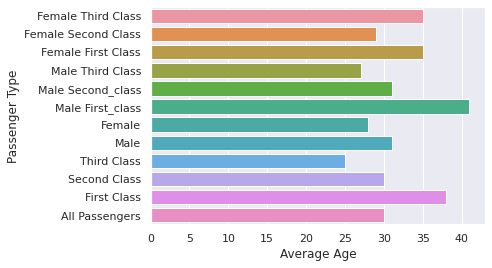

```python
_titanic.average_age()
```

```python
_titanic.average_age_df
```

|  | Passenger Type | Average Age |
| --- | --- | --- |
| 0 | Female Third Class | 35 |
| 1 | Female Second Class | 29 |
| 2 | Female First Class | 35 |
| 3 | Male Third Class | 27 |
| 4 | Male Second_class | 31 |
| 5 | Male First_class | 41 |
| 6 | Female | 28 |
| 7 | Male | 31 |
| 8 | Third Class | 25 |
| 9 | Second Class | 30 |
| 10 | First Class | 38 |
| 11 | All Passengers | 30 |

```python
_titanic.assign_missing_ages()
```

[output not shown]

[output cut: 218 more lines]

[output not shown]

# Historic Survival Rate

Beyond gender, passenger class was the greatest predictive variable. A male travelling first class had a higher survival rate than a male travelling either second or third class. First class passengers had a higher survival rate than second class passengers, who had a higher survival rate than third class passengers.

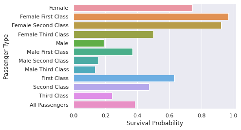

```python
_titanic.survival_summary()
```

```python
_titanic.survival_summary_df
```

|  | Passenger Type | Survival Probability |
| --- | --- | --- |
| 0 | Female | 0.742038 |
| 1 | Female First Class | 0.968085 |
| 2 | Female Second Class | 0.921053 |
| 3 | Female Third Class | 0.500000 |
| 4 | Male | 0.188908 |
| 5 | Male First Class | 0.368852 |
| 6 | Male Second Class | 0.157407 |
| 7 | Male Third Class | 0.135447 |
| 8 | First Class | 0.629630 |
| 9 | Second Class | 0.472826 |
| 10 | Third Class | 0.242363 |
| 11 | All Passengers | 0.383838 |

# All Passengers

## Non-Familial Features

```python
_titanic.non_familial_models(_titanic.all_passengers, _titanic.all_passengers_ages, 'A')
```

```
Gradient Boosting
              precision    recall  f1-score   support

           0       0.80      0.90      0.85       105
           1       0.83      0.68      0.75        74

    accuracy                           0.81       179
   macro avg       0.82      0.79      0.80       179
weighted avg       0.81      0.81      0.81       179

Decision Tree
              precision    recall  f1-score   support

           0       0.79      0.87      0.83       105
           1       0.78      0.68      0.72        74

    accuracy                           0.79       179
   macro avg       0.79      0.77      0.78       179
weighted avg       0.79      0.79      0.78       179

Stochastic Gradient Descent
              precision    recall  f1-score   support

           0       0.81      0.84      0.83       105
           1       0.76      0.73      0.74        74

    accuracy                           0.79       179
   macro avg       0.79      0.78      0.79       179
weighted avg       0.79      0.79      0.79       179

Gaussian
              precision    recall  f1-score   support

           0       0.80      0.82      0.81       105
           1       0.73      0.70      0.72        74

    accuracy                           0.77       179
   macro avg       0.76      0.76      0.76       179
weighted avg       0.77      0.77      0.77       179

```

[output cut: 34 more lines]

```
           1       0.90      0.50      0.64        74

    accuracy                           0.77       179
   macro avg       0.82      0.73      0.74       179
weighted avg       0.80      0.77      0.75       179

Multi Layer Perceptron
              precision    recall  f1-score   support

           0       0.75      0.92      0.83       105
           1       0.84      0.55      0.67        74

    accuracy                           0.77       179
   macro avg       0.79      0.74      0.75       179
weighted avg       0.78      0.77      0.76       179
```

## Familial Features

```python
_titanic.familial_models(_titanic.all_passengers, _titanic.all_passengers_ages, 'A')
```

```
Gradient Boosting
              precision    recall  f1-score   support

           0       0.80      0.91      0.85       105
           1       0.85      0.68      0.75        74

    accuracy                           0.82       179
   macro avg       0.82      0.79      0.80       179
weighted avg       0.82      0.82      0.81       179

                       Relationship Type  Survived
0         Travelling with Spouse Sibling       179
1                 Travelling with Parent       199
2  Travelling with Spouse Sibling Parent       173
3                       Travelling Alone       201

Decision Tree
              precision    recall  f1-score   support

           0       0.80      0.87      0.83       105
           1       0.78      0.69      0.73        74

    accuracy                           0.79       179
   macro avg       0.79      0.78      0.78       179
weighted avg       0.79      0.79      0.79       179

                       Relationship Type  Survived
0         Travelling with Spouse Sibling       186
1                 Travelling with Parent       196
2  Travelling with Spouse Sibling Parent       199
3                       Travelling Alone       200

Stochastic Gradient Descent
              precision    recall  f1-score   support

           0       0.75      0.68      0.71       105
           1       0.60      0.68      0.63        74

    accuracy                           0.68       179
   macro avg       0.67      0.68      0.67       179
```

[output cut: 88 more lines]

```
Multi Layer Perceptron
              precision    recall  f1-score   support

           0       0.77      0.90      0.83       105
           1       0.82      0.62      0.71        74

    accuracy                           0.79       179
   macro avg       0.80      0.76      0.77       179
weighted avg       0.79      0.79      0.78       179

                       Relationship Type  Survived
0         Travelling with Spouse Sibling       137
1                 Travelling with Parent       144
2  Travelling with Spouse Sibling Parent       236
3                       Travelling Alone       140
```

# Female Passengers

## Non-Familial Features

```python
_titanic.non_familial_models(_titanic.female, _titanic.female_ages, 'F')
```

```
Gradient Boosting
              precision    recall  f1-score   support

           0       0.67      0.33      0.44        18
           1       0.78      0.93      0.85        45

    accuracy                           0.76        63
   macro avg       0.72      0.63      0.65        63
weighted avg       0.75      0.76      0.73        63

Decision Tree
              precision    recall  f1-score   support

           0       0.67      0.44      0.53        18
           1       0.80      0.91      0.85        45

    accuracy                           0.78        63
   macro avg       0.74      0.68      0.69        63
weighted avg       0.76      0.78      0.76        63

Stochastic Gradient Descent
              precision    recall  f1-score   support

           0       0.34      0.61      0.44        18
           1       0.77      0.53      0.63        45

    accuracy                           0.56        63
   macro avg       0.56      0.57      0.54        63
weighted avg       0.65      0.56      0.58        63

Gaussian
              precision    recall  f1-score   support

           0       0.52      0.94      0.67        18
           1       0.97      0.64      0.77        45

    accuracy                           0.73        63
   macro avg       0.74      0.79      0.72        63
weighted avg       0.84      0.73      0.74        63

```

[output cut: 34 more lines]

```
           1       0.72      0.98      0.83        45

    accuracy                           0.71        63
   macro avg       0.61      0.52      0.47        63
weighted avg       0.66      0.71      0.62        63

Multi Layer Perceptron
              precision    recall  f1-score   support

           0       0.00      0.00      0.00        18
           1       0.71      1.00      0.83        45

    accuracy                           0.71        63
   macro avg       0.36      0.50      0.42        63
weighted avg       0.51      0.71      0.60        63
```

## Familial Features

```python
_titanic.familial_models(_titanic.female, _titanic.female_ages, 'F')
```

```
Gradient Boosting
              precision    recall  f1-score   support

           0       0.69      0.61      0.65        18
           1       0.85      0.89      0.87        45

    accuracy                           0.81        63
   macro avg       0.77      0.75      0.76        63
weighted avg       0.80      0.81      0.81        63

                       Relationship Type  Survived
0         Travelling with Spouse Sibling       134
1                 Travelling with Parent       130
2  Travelling with Spouse Sibling Parent       128
3                       Travelling Alone       143

Decision Tree
              precision    recall  f1-score   support

           0       0.56      0.50      0.53        18
           1       0.81      0.84      0.83        45

    accuracy                           0.75        63
   macro avg       0.69      0.67      0.68        63
weighted avg       0.74      0.75      0.74        63

                       Relationship Type  Survived
0         Travelling with Spouse Sibling       128
1                 Travelling with Parent       125
2  Travelling with Spouse Sibling Parent       123
3                       Travelling Alone       137

Stochastic Gradient Descent
              precision    recall  f1-score   support

           0       0.53      0.50      0.51        18
           1       0.80      0.82      0.81        45

    accuracy                           0.73        63
   macro avg       0.67      0.66      0.66        63
```

[output cut: 88 more lines]

```
Multi Layer Perceptron
              precision    recall  f1-score   support

           0       0.57      0.44      0.50        18
           1       0.80      0.87      0.83        45

    accuracy                           0.75        63
   macro avg       0.68      0.66      0.66        63
weighted avg       0.73      0.75      0.74        63

                       Relationship Type  Survived
0         Travelling with Spouse Sibling       177
1                 Travelling with Parent       118
2  Travelling with Spouse Sibling Parent       177
3                       Travelling Alone       177
```

# Male Passengers

## Non-Familial Features

```python
_titanic.non_familial_models(_titanic.male, _titanic.male_ages, 'M')
```

```
Gradient Boosting
              precision    recall  f1-score   support

           0       0.86      0.94      0.90        96
           1       0.45      0.25      0.32        20

    accuracy                           0.82       116
   macro avg       0.66      0.59      0.61       116
weighted avg       0.79      0.82      0.80       116

Decision Tree
              precision    recall  f1-score   support

           0       0.85      0.96      0.90        96
           1       0.50      0.20      0.29        20

    accuracy                           0.83       116
   macro avg       0.68      0.58      0.59       116
weighted avg       0.79      0.83      0.80       116

Stochastic Gradient Descent
              precision    recall  f1-score   support

           0       0.83      1.00      0.91        96
           1       0.00      0.00      0.00        20

    accuracy                           0.83       116
   macro avg       0.41      0.50      0.45       116
weighted avg       0.68      0.83      0.75       116

Gaussian
              precision    recall  f1-score   support

           0       0.89      0.81      0.85        96
           1       0.36      0.50      0.42        20

    accuracy                           0.76       116
   macro avg       0.62      0.66      0.63       116
weighted avg       0.80      0.76      0.77       116

```

[output cut: 34 more lines]

```
           1       1.00      0.10      0.18        20

    accuracy                           0.84       116
   macro avg       0.92      0.55      0.55       116
weighted avg       0.87      0.84      0.79       116

Multi Layer Perceptron
              precision    recall  f1-score   support

           0       0.85      0.96      0.90        96
           1       0.50      0.20      0.29        20

    accuracy                           0.83       116
   macro avg       0.68      0.58      0.59       116
weighted avg       0.79      0.83      0.80       116
```

## Familial Features

```python
_titanic.familial_models(_titanic.male, _titanic.male_ages, 'M')
```

```
Gradient Boosting
              precision    recall  f1-score   support

           0       0.87      0.95      0.91        96
           1       0.55      0.30      0.39        20

    accuracy                           0.84       116
   macro avg       0.71      0.62      0.65       116
weighted avg       0.81      0.84      0.82       116

                       Relationship Type  Survived
0         Travelling with Spouse Sibling        33
1                 Travelling with Parent        34
2  Travelling with Spouse Sibling Parent        37
3                       Travelling Alone        35

Decision Tree
              precision    recall  f1-score   support

           0       0.86      0.93      0.89        96
           1       0.42      0.25      0.31        20

    accuracy                           0.81       116
   macro avg       0.64      0.59      0.60       116
weighted avg       0.78      0.81      0.79       116

                       Relationship Type  Survived
0         Travelling with Spouse Sibling        36
1                 Travelling with Parent        37
2  Travelling with Spouse Sibling Parent        48
3                       Travelling Alone        45

Stochastic Gradient Descent
              precision    recall  f1-score   support

           0       0.86      0.92      0.89        96
           1       0.43      0.30      0.35        20

    accuracy                           0.81       116
   macro avg       0.65      0.61      0.62       116
```

[output cut: 88 more lines]

```
Multi Layer Perceptron
              precision    recall  f1-score   support

           0       0.84      0.96      0.90        96
           1       0.43      0.15      0.22        20

    accuracy                           0.82       116
   macro avg       0.64      0.55      0.56       116
weighted avg       0.77      0.82      0.78       116

                       Relationship Type  Survived
0         Travelling with Spouse Sibling        27
1                 Travelling with Parent         1
2  Travelling with Spouse Sibling Parent         0
3                       Travelling Alone         0
```

# Third Class Passengers

## Non-Familial

```python
_titanic.non_familial_models(_titanic.third_class, _titanic.third_class_ages, 'A')
```

```
Gradient Boosting
              precision    recall  f1-score   support

           0       0.88      0.80      0.84        82
           1       0.33      0.47      0.39        17

    accuracy                           0.75        99
   macro avg       0.61      0.64      0.62        99
weighted avg       0.79      0.75      0.76        99

Decision Tree
              precision    recall  f1-score   support

           0       0.87      0.83      0.85        82
           1       0.33      0.41      0.37        17

    accuracy                           0.76        99
   macro avg       0.60      0.62      0.61        99
weighted avg       0.78      0.76      0.77        99

Stochastic Gradient Descent
              precision    recall  f1-score   support

           0       0.94      0.76      0.84        82
           1       0.39      0.76      0.52        17

    accuracy                           0.76        99
   macro avg       0.67      0.76      0.68        99
weighted avg       0.85      0.76      0.78        99

Gaussian
              precision    recall  f1-score   support

           0       0.91      0.78      0.84        82
           1       0.38      0.65      0.48        17

    accuracy                           0.76        99
   macro avg       0.65      0.71      0.66        99
weighted avg       0.82      0.76      0.78        99

```

[output cut: 34 more lines]

```
           1       0.39      0.65      0.49        17

    accuracy                           0.77        99
   macro avg       0.65      0.72      0.67        99
weighted avg       0.83      0.77      0.79        99

Multi Layer Perceptron
              precision    recall  f1-score   support

           0       0.90      0.79      0.84        82
           1       0.37      0.59      0.45        17

    accuracy                           0.76        99
   macro avg       0.64      0.69      0.65        99
weighted avg       0.81      0.76      0.78        99
```

## Familial

```python
_titanic.familial_models(_titanic.third_class, _titanic.third_class_ages, 'A')
```

```
Gradient Boosting
              precision    recall  f1-score   support

           0       0.89      0.82      0.85        82
           1       0.38      0.53      0.44        17

    accuracy                           0.77        99
   macro avg       0.63      0.67      0.65        99
weighted avg       0.80      0.77      0.78        99

                       Relationship Type  Survived
0         Travelling with Spouse Sibling       102
1                 Travelling with Parent        90
2  Travelling with Spouse Sibling Parent        63
3                       Travelling Alone       114

Decision Tree
              precision    recall  f1-score   support

           0       0.88      0.83      0.86        82
           1       0.36      0.47      0.41        17

    accuracy                           0.77        99
   macro avg       0.62      0.65      0.63        99
weighted avg       0.79      0.77      0.78        99

                       Relationship Type  Survived
0         Travelling with Spouse Sibling       108
1                 Travelling with Parent        60
2  Travelling with Spouse Sibling Parent        39
3                       Travelling Alone       105

Stochastic Gradient Descent
              precision    recall  f1-score   support

           0       0.91      0.83      0.87        82
           1       0.42      0.59      0.49        17

    accuracy                           0.79        99
   macro avg       0.66      0.71      0.68        99
```

[output cut: 88 more lines]

```
Multi Layer Perceptron
              precision    recall  f1-score   support

           0       0.90      0.84      0.87        82
           1       0.41      0.53      0.46        17

    accuracy                           0.79        99
   macro avg       0.65      0.69      0.66        99
weighted avg       0.81      0.79      0.80        99

                       Relationship Type  Survived
0         Travelling with Spouse Sibling       133
1                 Travelling with Parent        69
2  Travelling with Spouse Sibling Parent         9
3                       Travelling Alone       131
```

# Second Class Passengers

## Non-Familial

```python
_titanic.non_familial_models(_titanic.second_class, _titanic.second_class_ages, 'A')
```

```
Gradient Boosting
              precision    recall  f1-score   support

           0       1.00      0.84      0.91        19
           1       0.86      1.00      0.92        18

    accuracy                           0.92        37
   macro avg       0.93      0.92      0.92        37
weighted avg       0.93      0.92      0.92        37

Decision Tree
              precision    recall  f1-score   support

           0       0.94      0.84      0.89        19
           1       0.85      0.94      0.89        18

    accuracy                           0.89        37
   macro avg       0.90      0.89      0.89        37
weighted avg       0.90      0.89      0.89        37

Stochastic Gradient Descent
              precision    recall  f1-score   support

           0       0.89      0.42      0.57        19
           1       0.61      0.94      0.74        18

    accuracy                           0.68        37
   macro avg       0.75      0.68      0.66        37
weighted avg       0.75      0.68      0.65        37

Gaussian
              precision    recall  f1-score   support

           0       0.94      0.84      0.89        19
           1       0.85      0.94      0.89        18

    accuracy                           0.89        37
   macro avg       0.90      0.89      0.89        37
weighted avg       0.90      0.89      0.89        37

```

[output cut: 34 more lines]

```
           1       0.86      1.00      0.92        18

    accuracy                           0.92        37
   macro avg       0.93      0.92      0.92        37
weighted avg       0.93      0.92      0.92        37

Multi Layer Perceptron
              precision    recall  f1-score   support

           0       1.00      0.84      0.91        19
           1       0.86      1.00      0.92        18

    accuracy                           0.92        37
   macro avg       0.93      0.92      0.92        37
weighted avg       0.93      0.92      0.92        37
```

## Familial

```python
_titanic.familial_models(_titanic.second_class, _titanic.second_class_ages, 'A')
```

```
Gradient Boosting
              precision    recall  f1-score   support

           0       0.94      0.84      0.89        19
           1       0.85      0.94      0.89        18

    accuracy                           0.89        37
   macro avg       0.90      0.89      0.89        37
weighted avg       0.90      0.89      0.89        37

                       Relationship Type  Survived
0         Travelling with Spouse Sibling       177
1                 Travelling with Parent       180
2  Travelling with Spouse Sibling Parent       177
3                       Travelling Alone       177

Decision Tree
              precision    recall  f1-score   support

           0       0.94      0.84      0.89        19
           1       0.85      0.94      0.89        18

    accuracy                           0.89        37
   macro avg       0.90      0.89      0.89        37
weighted avg       0.90      0.89      0.89        37

                       Relationship Type  Survived
0         Travelling with Spouse Sibling       177
1                 Travelling with Parent       177
2  Travelling with Spouse Sibling Parent       168
3                       Travelling Alone       168

Stochastic Gradient Descent
              precision    recall  f1-score   support

           0       1.00      0.37      0.54        19
           1       0.60      1.00      0.75        18

    accuracy                           0.68        37
   macro avg       0.80      0.68      0.64        37
```

[output cut: 88 more lines]

```
Multi Layer Perceptron
              precision    recall  f1-score   support

           0       1.00      0.84      0.91        19
           1       0.86      1.00      0.92        18

    accuracy                           0.92        37
   macro avg       0.93      0.92      0.92        37
weighted avg       0.93      0.92      0.92        37

                       Relationship Type  Survived
0         Travelling with Spouse Sibling       159
1                 Travelling with Parent       178
2  Travelling with Spouse Sibling Parent       174
3                       Travelling Alone       159
```